# PAC Report_Shanrong Zhou

Shanrong Zhou

2022-11-18

This report summarizes and illustrates the data analysis process that I’ve done for Predictive Analysis Competition Project.

# Load Packages

Before I start doing anything, I loaded all the packages needed first, so that I won’t accidentally load any packages for multiple times.

```r
#data exploration and tidying
library(dplyr)
library(tidyr)
library(stringr)
library(caTools)
library(caret)
library(janitor)
```

```r
library(skimr)
library(ggcorrplot)
#intersect
library(base)
#create dummy variable
library(vtreat)
#regression tree
library(rpart); library(rpart.plot)
#bag ipred
library(ipred)
#random Forest
library(randomForest)
#ranger
library(ranger)
#gbm
library(gbm)
#xgboost
library(xgboost)
#box cox transformation and svm
library(e1071)
```

# Data Exploration

## Read Data

The first step is to set up the environment and import analysisData and scoringData.

```r
setwd("/Users/alicezhou/Documents/Columbia/5200 Applied Analytics Frameworks & Methods I/Notes/PAC")
data = read.csv("analysisData.csv")
sdata = read.csv(file="scoringData.csv")
```

## Variable Overview

Summary and comparison of two data sets are shown below. Here are some highlights and my thoughts for further analysis.

analysisData:

1. There are 19 variables, with 1 identifier (id) and 1 outcome / dependent variable (rating). The other variables can all be the potential predictors / independent variables to predictive models.
2. Outcome variable (rating) is continuous. Only models for continuous outcome variable should be considered, while logistics regression and classification trees can be excluded.
3. Predictors include categorical and continuous variables.
4. It’s easier to explore the numeric and logical data types’ characteristics by reading the overall summary. I can get a preliminary understanding, in terms of dispersion (standard deviation, interquartile range and range) for numeric variables and central tendency (mean) for both numeric and logical variables.
5. The character data type has more uniqueness and is less structured than the others.
   - song: It has 16,542 unique values, which is a similar amount to number of observations 19,485. Almost each song has its own name. This variable is too unique to be predictive. Therefore, I won’t include it as the predictor for future modelling.
   - genre: It has only 2,937 unique values. However, every value may contain several genres of a song. I am going to remove the special characters, and transform it to new categorical variables, so that each genre type can be represented by a category individually. Besides, since it contains missing value, I will fill the missing value as 0 before data transformation.
   - performer: It has 6,687 unique values. Around 1/3 of songs have their unique performers. It’s reasonable to be considered as a predictive variable now.

Comparison between analysisData and scoringData:

1. Compared to the variables of analysisData, only outcome variable (rating) is missed for scoringData. All the predictors are in same data type. We can use all the predictors in analysisData to train the predictive model, to predict rating of songs in scoringData.
2. There are significantly less rows for scoringData than analysisData. Some characters of genre and performer can be different from analysisData. Thus, I will only include the inter-sets of both data sets for these variables to data analysis.

```r
str(data)
```

```
## 'data.frame':    19485 obs. of  19 variables:
##  $ id              : int  94500 64901 28440 19804 83560 16501 58033 67048 48848 95622 ...
##  $ performer       : chr  "Andy Williams" "Sandy Nelson" "Britney Spears" "Taylor Swift" ...
##  $ song            : chr  "......And Roses And Roses" "...And Then There Were Drums" "...Baby One More Time" "...Ready For It?" ...
##  $ genre           : chr  "['adult standards', 'brill building pop', 'easy listening', 'mellow gold']" "['rock-and-roll', 'space age pop', 'surf music']" "['dance pop', 'pop', 'post-teen pop']" "['pop', 'post-teen pop']" ...
##  $ track_duration  : num  166106 172066 211066 208186 182080 ...
##  $ track_explicit  : logi  FALSE FALSE FALSE FALSE FALSE FALSE ...
##  $ danceability    : num  0.154 0.588 0.759 0.613 0.45 0.57 0.612 0.253 0.575 0.615 ...
##  $ energy          : num  0.185 0.672 0.699 0.764 0.294 0.629 0.542 0.232 0.434 0.497 ...
##  $ key             : int  5 11 0 2 7 9 5 0 5 7 ...
##  $ loudness        : num  -14.06 -17.28 -5.75 -6.51 -12.02 ...
##  $ mode            : int  1 0 0 1 1 0 1 1 1 1 ...
##  $ speechiness     : num  0.0315 0.0361 0.0307 0.136 0.0318 0.0331 0.0264 0.0318 0.0312 0.439 ...
##  $ acousticness    : num  0.911 0.00256 0.202 0.0527 0.832 0.593 0.0781 0.805 0.735 0.016 ...
##  $ instrumentalness: num  2.67e-04 7.45e-01 1.31e-04 0.00 3.53e-05 1.36e-04 0.00 1.80e-04 6.59e-05 0.00 ...
##  $ liveness        : num  0.112 0.145 0.443 0.197 0.108 0.77 0.0763 0.0939 0.105 0.312 ...
##  $ valence         : num  0.15 0.801 0.907 0.417 0.146 0.308 0.433 0.307 0.348 0.769 ...
##  $ tempo           : num  84 122 93 160 141 ...
##  $ time_signature  : int  4 4 4 4 4 4 4 3 4 3 ...
##  $ rating          : int  36 16 70 64 19 34 44 34 47 26 ...
```

```r
skim(data)
```

Data summary

| Name | data |
| --- | --- |
| Number of rows | 19485 |
| Number of columns | 19 |
| _______________________ |  |
| Column type frequency: |  |
| character | 3 |
| logical | 1 |
| numeric | 15 |
| ________________________ |  |
| Group variables | None |

**Variable type: character**

| skim_variable | n_missing | complete_rate | min | max | empty | n_unique | whitespace |
| --- | --- | --- | --- | --- | --- | --- | --- |
| performer | 0 | 1.00 | 1 | 113 | 0 | 6687 | 0 |
| song | 0 | 1.00 | 1 | 75 | 0 | 16542 | 0 |
| genre | 108 | 0.99 | 2 | 319 | 0 | 2937 | 0 |

**Variable type: logical**

| skim_variable | n_missing | complete_rate | mean | count |
| --- | --- | --- | --- | --- |
| track_explicit | 0 | 1 | 0.12 | FAL: 17203, TRU: 2282 |

**Variable type: numeric**

| skim_variable | n_missing | complete_rate | mean | sd | p0 | p25 | p50 | p75 | p100 | hist |
| --- | --- | --- | --- | --- | --- | --- | --- | --- | --- | --- |
| id | 0 | 1 | 50208.92 | 29047.37 | 3.00 | 24812.00 | 50487.00 | 75544.00 | 99999.00 | ▇▇▇▇▇ |
| track_duration | 0 | 1 | 220873.01 | 68749.76 | 29688.00 | 175173.00 | 214733.00 | 253306.00 | 3079157.00 | ▇▁▁▁▁ |
| danceability | 0 | 1 | 0.60 | 0.15 | 0.00 | 0.50 | 0.61 | 0.71 | 0.99 | ▁▂▆▇▂ |
| energy | 0 | 1 | 0.62 | 0.20 | 0.00 | 0.48 | 0.63 | 0.78 | 1.00 | ▁▃▆▇▅ |
| key | 0 | 1 | 5.23 | 3.56 | 0.00 | 2.00 | 5.00 | 8.00 | 11.00 | ▇▃▃▅▆ |
| loudness | 0 | 1 | -8.67 | 3.61 | -28.03 | -11.04 | -8.21 | -5.86 | 2.29 | ▁▁▅▇▁ |
| mode | 0 | 1 | 0.73 | 0.44 | 0.00 | 0.00 | 1.00 | 1.00 | 1.00 | ▃▁▁▁▇ |
| speechiness | 0 | 1 | 0.07 | 0.08 | 0.00 | 0.03 | 0.04 | 0.07 | 0.92 | ▇▁▁▁▁ |
| acousticness | 0 | 1 | 0.29 | 0.28 | 0.00 | 0.05 | 0.19 | 0.51 | 0.99 | ▇▃▂▂▁ |
| instrumentalness | 0 | 1 | 0.03 | 0.14 | 0.00 | 0.00 | 0.00 | 0.00 | 0.98 | ▇▁▁▁▁ |
| liveness | 0 | 1 | 0.19 | 0.16 | 0.01 | 0.09 | 0.13 | 0.25 | 1.00 | ▇▂▁▁▁ |
| valence | 0 | 1 | 0.60 | 0.24 | 0.00 | 0.41 | 0.62 | 0.80 | 0.99 | ▂▅▇▇▇ |
| tempo | 0 | 1 | 120.24 | 27.92 | 0.00 | 99.08 | 119.00 | 136.39 | 241.01 | ▁▃▇▂▁ |
| time_signature | 0 | 1 | 3.93 | 0.32 | 0.00 | 4.00 | 4.00 | 4.00 | 5.00 | ▁▁▁▇▁ |
| rating | 0 | 1 | 36.69 | 16.55 | 0.00 | 24.00 | 36.00 | 50.00 | 91.00 | ▃▇▇▃▁ |

```r
str(sdata)
```

```
## 'data.frame':    4844 obs. of  18 variables:
##  $ id              : int  50400 96747 1824 67597 86944 85423 5500 82675 5926 57666 ...
##  $ performer       : chr  "Paul Davis" "Luther Vandross" "The Olympics" "Maxine Nightingale" ...
##  $ song            : chr  "'65 Love Affair" "'Til My Baby Comes Home" "(Baby) Hully Gully" "(Bringing Out) The Girl In Me" ...
##  $ genre           : chr  "['album rock', 'bubblegum pop', 'country rock', 'folk rock', 'mellow gold', 'new wave pop', 'soft rock', 'yacht rock']" "['funk', 'motown', 'neo soul', 'new jack swing', 'quiet storm', 'r&b', 'soul', 'urban contemporary']" "['doo-wop', 'rhythm and blues']" "['classic uk…
##  $ track_duration  : num  219813 332226 127829 210973 180133 ...
##  $ track_explicit  : logi  FALSE FALSE FALSE FALSE FALSE FALSE ...
##  $ danceability    : num  0.647 0.804 0.744 0.712 0.665 0.442 0.61 0.478 0.499 0.801 ...
##  $ energy          : num  0.686 0.714 0.47 0.753 0.552 0.717 0.377 0.298 0.249 0.875 ...
##  $ key             : int  2 11 7 9 6 9 9 2 5 7 ...
##  $ loudness        : num  -4.25 -6.71 -10.29 -7.67 -10.18 ...
##  $ mode            : int  0 0 1 1 1 0 1 1 1 1 ...
##  $ speechiness     : num  0.0274 0.183 0.035 0.0399 0.0307 0.0395 0.0935 0.0342 0.0422 0.0995 ...
##  $ acousticness    : num  0.432 0.0567 0.659 0.756 0.493 0.518 0.414 0.74 0.733 0.00366 ...
##  $ instrumentalness: num  6.19e-06 6.21e-06 0.00 1.58e-06 2.72e-02 2.62e-01 0.00 1.11e-05 0.00 4.25e-01 ...
##  $ liveness        : num  0.133 0.0253 0.256 0.169 0.421 0.184 0.0734 0.139 0.105 0.182 ...
##  $ valence         : num  0.952 0.802 0.908 0.953 0.899 0.376 0.519 0.376 0.539 0.637 ...
##  $ tempo           : num  155.7 139.7 116.2 116.2 96.9 ...
##  $ time_signature  : int  4 4 4 4 4 4 4 4 4 4 ...
```

```r
skim(sdata)
```

Data summary

| Name | sdata |
| --- | --- |
| Number of rows | 4844 |
| Number of columns | 18 |
| _______________________ |  |
| Column type frequency: |  |
| character | 3 |
| logical | 1 |
| numeric | 14 |
| ________________________ |  |
| Group variables | None |

**Variable type: character**

| skim_variable | n_missing | complete_rate | min | max | empty | n_unique | whitespace |
| --- | --- | --- | --- | --- | --- | --- | --- |
| performer | 0 | 1.00 | 2 | 72 | 0 | 2791 | 0 |
| song | 0 | 1.00 | 1 | 67 | 0 | 4604 | 0 |
| genre | 36 | 0.99 | 2 | 312 | 0 | 1702 | 0 |

**Variable type: logical**

| skim_variable | n_missing | complete_rate | mean | count |
| --- | --- | --- | --- | --- |
| track_explicit | 0 | 1 | 0.13 | FAL: 4213, TRU: 631 |

**Variable type: numeric**

| skim_variable | n_missing | complete_rate | mean | sd | p0 | p25 | p50 | p75 | p100 | hist |
| --- | --- | --- | --- | --- | --- | --- | --- | --- | --- | --- |
| id | 0 | 1 | 49953.08 | 28769.94 | 8.00 | 25172.75 | 49678.00 | 75322.75 | 99980.00 | ▇▇▇▇▇ |
| track_duration | 0 | 1 | 219882.00 | 63667.02 | 37013.00 | 174533.00 | 215152.50 | 252896.25 | 688453.00 | ▂▇▁▁▁ |
| danceability | 0 | 1 | 0.60 | 0.15 | 0.11 | 0.50 | 0.61 | 0.71 | 0.97 | ▁▃▇▇▂ |
| energy | 0 | 1 | 0.62 | 0.20 | 0.02 | 0.48 | 0.64 | 0.78 | 1.00 | ▁▃▇▇▅ |
| key | 0 | 1 | 5.24 | 3.56 | 0.00 | 2.00 | 5.00 | 8.00 | 11.00 | ▇▃▃▅▆ |
| loudness | 0 | 1 | -8.63 | 3.55 | -25.47 | -11.02 | -8.19 | -5.86 | -0.51 | ▁▁▅▇▃ |
| mode | 0 | 1 | 0.72 | 0.45 | 0.00 | 0.00 | 1.00 | 1.00 | 1.00 | ▃▁▁▁▇ |
| speechiness | 0 | 1 | 0.08 | 0.08 | 0.02 | 0.03 | 0.04 | 0.07 | 0.95 | ▇▁▁▁▁ |
| acousticness | 0 | 1 | 0.30 | 0.28 | 0.00 | 0.05 | 0.20 | 0.52 | 0.98 | ▇▃▂▂▁ |
| instrumentalness | 0 | 1 | 0.03 | 0.13 | 0.00 | 0.00 | 0.00 | 0.00 | 0.96 | ▇▁▁▁▁ |
| liveness | 0 | 1 | 0.19 | 0.15 | 0.01 | 0.09 | 0.13 | 0.24 | 0.99 | ▇▂▁▁▁ |
| valence | 0 | 1 | 0.60 | 0.24 | 0.04 | 0.42 | 0.63 | 0.80 | 0.98 | ▂▅▆▇▇ |
| tempo | 0 | 1 | 120.41 | 28.55 | 37.11 | 99.00 | 118.23 | 136.80 | 216.20 | ▁▆▇▂▁ |
| time_signature | 0 | 1 | 3.93 | 0.33 | 1.00 | 4.00 | 4.00 | 4.00 | 5.00 | ▁▁▁▇▁ |

# Data Tidying

## Encode Missing Data

```r
data[is.na(data)] = 0
```

## Data Parsing

For character type of data, since some variables contain observations with multiple delimited values, I am going to separate the values and places each one in its own row. Moreover, special character and unnecessary space have to be removed.

```r
data1 <- data

#character data - performer
##seperate a collapsed column into multiple rows, so that each row only indicates 1 performer
data1 <- data1 %>%
  separate_rows(performer, sep = ",")
##remove special character
data1$performer <- gsub("[^[:alnum:] ]","",data1$performer)

#character data - genre
##seperate a collapsed column into multiple rows, so that each row only indicates 1 genre
data1 <- data1 %>%
  separate_rows(genre, sep = ",")
##remove special character
data1$genre <- gsub("[^[:alnum:] ]","",data1$genre)
##remove both leading and trailing whitespace
data1$genre <- trimws(data1$genre)

head(data1)
```

```
## # A tibble: 6 × 19
##      id performer song  genre track…¹ track…² dance…³ energy   key loudn…⁴  mode
##   <int> <chr>     <chr> <chr>   <dbl> <lgl>     <dbl>  <dbl> <int>   <dbl> <int>
## 1 94500 Andy Wil… ....… adul…  166106 FALSE     0.154  0.185     5   -14.1     1
## 2 94500 Andy Wil… ....… bril…  166106 FALSE     0.154  0.185     5   -14.1     1
## 3 94500 Andy Wil… ....… easy…  166106 FALSE     0.154  0.185     5   -14.1     1
## 4 94500 Andy Wil… ....… mell…  166106 FALSE     0.154  0.185     5   -14.1     1
## 5 64901 Sandy Ne… ...A… rock…  172066 FALSE     0.588  0.672    11   -17.3     0
## 6 64901 Sandy Ne… ...A… spac…  172066 FALSE     0.588  0.672    11   -17.3     0
## # … with 8 more variables: speechiness <dbl>, acousticness <dbl>,
## #   instrumentalness <dbl>, liveness <dbl>, valence <dbl>, tempo <dbl>,
## #   time_signature <int>, rating <int>, and abbreviated variable names
## #   ¹track_duration, ²track_explicit, ³danceability, ⁴loudness
```

As a result, we can see the observations are separated to multiple rows, and each row only indicates 1 genre and 1 performer. For example, the first observation (id: 94500), has been separated to 4 rows, because it represents 4 genres and 1 performer.

## Data Transformation

It’s hard to directly input logical and character data into models, so I am going to change them to either numeric or factor data type. Furthermore, to prepare future data analysis (eg. Principal Components Analysis), I will change integer to numeric data.

```r
#data type transformation: logical to numeric
data1$track_explicit <- ifelse(data1$track_explicit==TRUE, 1, 0)
#data type transformation: character to factor
data1$performer <- as.factor(data1$performer)
data1$genre <- as.factor(data1$genre)
#data type transformation: integer to numeric
data1$rating <- as.numeric(data1$rating)
data1$key <- as.numeric(data1$key)
data1$mode <- as.numeric(data1$mode)
data1$time_signature <- as.numeric(data1$time_signature)

skim(data1)
```

Data summary

| Name | data1 |
| --- | --- |
| Number of rows | 96654 |
| Number of columns | 19 |
| _______________________ |  |
| Column type frequency: |  |
| character | 1 |
| factor | 2 |
| numeric | 16 |
| ________________________ |  |
| Group variables | None |

**Variable type: character**

| skim_variable | n_missing | complete_rate | min | max | empty | n_unique | whitespace |
| --- | --- | --- | --- | --- | --- | --- | --- |
| song | 0 | 1 | 1 | 75 | 0 | 16542 | 0 |

**Variable type: factor**

| skim_variable | n_missing | complete_rate | ordered | n_unique | top_counts |
| --- | --- | --- | --- | --- | --- |
| performer | 0 | 1 | FALSE | 6869 | Dra: 468, Gle: 441, Dio: 370, Jac: 320 |
| genre | 0 | 1 | FALSE | 996 | mel: 2985, sof: 2830, adu: 2613, roc: 2462 |

**Variable type: numeric**

| skim_variable | n_missing | complete_rate | mean | sd | p0 | p25 | p50 | p75 | p100 | hist |
| --- | --- | --- | --- | --- | --- | --- | --- | --- | --- | --- |
| id | 0 | 1 | 50075.79 | 29019.08 | 3.00 | 24669.00 | 50317.00 | 75491.00 | 99999.00 | ▇▇▇▇▇ |
| track_duration | 0 | 1 | 224863.68 | 67397.37 | 29688.00 | 178906.00 | 219054.50 | 257686.25 | 3079157.00 | ▇▁▁▁▁ |
| track_explicit | 0 | 1 | 0.13 | 0.33 | 0.00 | 0.00 | 0.00 | 0.00 | 1.00 | ▇▁▁▁▁ |
| danceability | 0 | 1 | 0.60 | 0.15 | 0.00 | 0.50 | 0.61 | 0.71 | 0.99 | ▁▂▇▇▂ |
| energy | 0 | 1 | 0.62 | 0.20 | 0.00 | 0.48 | 0.64 | 0.78 | 1.00 | ▁▃▆▇▅ |
| key | 0 | 1 | 5.22 | 3.55 | 0.00 | 2.00 | 5.00 | 8.00 | 11.00 | ▇▃▃▅▆ |
| loudness | 0 | 1 | -8.72 | 3.60 | -28.03 | -11.07 | -8.27 | -5.96 | 2.29 | ▁▁▅▇▁ |
| mode | 0 | 1 | 0.73 | 0.45 | 0.00 | 0.00 | 1.00 | 1.00 | 1.00 | ▃▁▁▁▇ |
| speechiness | 0 | 1 | 0.07 | 0.08 | 0.00 | 0.03 | 0.04 | 0.07 | 0.92 | ▇▁▁▁▁ |
| acousticness | 0 | 1 | 0.28 | 0.27 | 0.00 | 0.05 | 0.19 | 0.48 | 0.99 | ▇▃▂▂▁ |
| instrumentalness | 0 | 1 | 0.03 | 0.12 | 0.00 | 0.00 | 0.00 | 0.00 | 0.98 | ▇▁▁▁▁ |
| liveness | 0 | 1 | 0.19 | 0.16 | 0.01 | 0.09 | 0.13 | 0.25 | 1.00 | ▇▂▁▁▁ |
| valence | 0 | 1 | 0.61 | 0.24 | 0.00 | 0.43 | 0.63 | 0.80 | 0.99 | ▂▅▆▇▇ |
| tempo | 0 | 1 | 120.46 | 27.81 | 0.00 | 99.48 | 119.04 | 136.51 | 241.01 | ▁▃▇▂▁ |
| time_signature | 0 | 1 | 3.94 | 0.31 | 0.00 | 4.00 | 4.00 | 4.00 | 5.00 | ▁▁▁▇▁ |
| rating | 0 | 1 | 37.67 | 15.93 | 0.00 | 26.00 | 38.00 | 50.00 | 91.00 | ▃▇▇▃▁ |

Even though character data has been transformed to factor, it cannot be integrated over, summed over, or marginalized for further data analysis. Thus, I am going to create dummy variables so that these variables can be used in many machine learning models.

```r
#create dummy variable - genre
data2 <- data1 %>%
    mutate(n=1) %>%
    pivot_wider(names_from=genre, values_from=n, names_prefix="genre_", values_fill=list(n=0))
#create dummy variable - performer
data2 <- data2 %>%
    mutate(n=1) %>%
    pivot_wider(names_from=performer, values_from=n, names_prefix="performer_", values_fill=list(n=0))
```

To extract more specific data sets for further variable selection, I drop the variables (id & song) that has been excluded to data analysis.

```r
#delete unused variables
data3 <- data2 %>% select(-id) %>% select(-song)

str(data3)
```

```
## tibble [19,485 × 7,880] (S3: tbl_df/tbl/data.frame)
##  $ track_duration                                                                         : num [1:19485] 166106 172066 211066 208186 182080 ...
##  $ track_explicit                                                                         : num [1:19485] 0 0 0 0 0 0 0 0 0 0 ...
##  $ danceability                                                                           : num [1:19485] 0.154 0.588 0.759 0.613 0.45 0.57 0.612 0.253 0.575 0.615 ...
##  $ energy                                                                                 : num [1:19485] 0.185 0.672 0.699 0.764 0.294 0.629 0.542 0.232 0.434 0.497 ...
##  $ key                                                                                    : num [1:19485] 5 11 0 2 7 9 5 0 5 7 ...
##  $ loudness                                                                               : num [1:19485] -14.06 -17.28 -5.75 -6.51 -12.02 ...
##  $ mode                                                                                   : num [1:19485] 1 0 0 1 1 0 1 1 1 1 ...
##  $ speechiness                                                                            : num [1:19485] 0.0315 0.0361 0.0307 0.136 0.0318 0.0331 0.0264 0.0318 0.0312 0.439 ...
##  $ acousticness                                                                           : num [1:19485] 0.911 0.00256 0.202 0.0527 0.832 0.593 0.0781 0.805 0.735 0.016 ...
##  $ instrumentalness                                                                       : num [1:19485] 2.67e-04 7.45e-01 1.31e-04 0.00 3.53e-05 1.36e-04 0.00 1.80e-04 6.59e-05 0.00 ...
##  $ liveness                                                                               : num [1:19485] 0.112 0.145 0.443 0.197 0.108 0.77 0.0763 0.0939 0.105 0.312 ...
##  $ valence                                                                                : num [1:19485] 0.15 0.801 0.907 0.417 0.146 0.308 0.433 0.307 0.348 0.769 ...
##  $ tempo                                                                                  : num [1:19485] 84 122 93 160 141 ...
##  $ time_signature                                                                         : num [1:19485] 4 4 4 4 4 4 4 3 4 3 ...
```

[output cut: 86 more lines]

Now, the analysisData contains same rows of observation as original, meanwhile it contains the dummy variables derived by performer and genre. Each dummy variable represents a category of either performer or genre.

I am going to perform the same data tidying process for scoringData, before we check the inter-sets of variables/columns between two data sets.

```r
#Encode Missing Data
sdata[is.na(sdata)] = 0

#Data Parsing
sdata1 <- sdata
#character data - performer
##seperate a collapsed column into multiple rows, so that each row only indicates 1 performer
sdata1 <- sdata1 %>%
  separate_rows(performer, sep = ",")
##remove special character
sdata1$performer <- gsub("[^[:alnum:] ]","",sdata1$performer)

#character data - genre
##seperate a collapsed column into multiple rows, so that each row only indicates 1 genre
sdata1 <- sdata1 %>%
  separate_rows(genre, sep = ",")
##remove special character
sdata1$genre <- gsub("[^[:alnum:] ]","",sdata1$genre)
##remove both leading and trailing whitespace
sdata1$genre <- trimws(sdata1$genre)

#Data Transformation
#data type transformation: logical to numeric
sdata1$track_explicit <- ifelse(sdata1$track_explicit==TRUE, 1, 0)
#data type transformation: character to factor
sdata1$performer <- as.factor(sdata1$performer)
sdata1$genre <- as.factor(sdata1$genre)
#data type transformation: integer to numeric
sdata1$key <- as.numeric(sdata1$key)
sdata1$mode <- as.numeric(sdata1$mode)
sdata1$time_signature <- as.numeric(sdata1$time_signature)

#create dummy variables - genre
sdata2 <- sdata1 %>%
    mutate(n=1) %>%
    pivot_wider(names_from=genre, values_from=n, names_prefix="genre_", values_fill=list(n=0))
#create dummy variables - performer
sdata2 <- sdata2 %>%
    mutate(n=1) %>%
    pivot_wider(names_from=performer, values_from=n, names_prefix="performer_", values_fill=list(n=0))

#delete unused variables
sdata3 <- sdata2 %>% select(-id) %>% select(-song)

str(sdata3)
```

```
## tibble [4,844 × 3,500] (S3: tbl_df/tbl/data.frame)
##  $ track_duration                                                                    : num [1:4844] 219813 332226 127829 210973 180133 ...
##  $ track_explicit                                                                    : num [1:4844] 0 0 0 0 0 0 0 0 0 0 ...
##  $ danceability                                                                      : num [1:4844] 0.647 0.804 0.744 0.712 0.665 0.442 0.61 0.478 0.499 0.801 ...
##  $ energy                                                                            : num [1:4844] 0.686 0.714 0.47 0.753 0.552 0.717 0.377 0.298 0.249 0.875 ...
##  $ key                                                                               : num [1:4844] 2 11 7 9 6 9 9 2 5 7 ...
##  $ loudness                                                                          : num [1:4844] -4.25 -6.71 -10.29 -7.67 -10.18 ...
##  $ mode                                                                              : num [1:4844] 0 0 1 1 1 0 1 1 1 1 ...
##  $ speechiness                                                                       : num [1:4844] 0.0274 0.183 0.035 0.0399 0.0307 0.0395 0.0935 0.0342 0.0422 0.0995 ...
##  $ acousticness                                                                      : num [1:4844] 0.432 0.0567 0.659 0.756 0.493 0.518 0.414 0.74 0.733 0.00366 ...
##  $ instrumentalness                                                                  : num [1:4844] 6.19e-06 6.21e-06 0.00 1.58e-06 2.72e-02 2.62e-01 0.00 1.11e-05 0.00 4.25e-01 ...
##  $ liveness                                                                          : num [1:4844] 0.133 0.0253 0.256 0.169 0.421 0.184 0.0734 0.139 0.105 0.182 ...
##  $ valence                                                                           : num [1:4844] 0.952 0.802 0.908 0.953 0.899 0.376 0.519 0.376 0.539 0.637 ...
##  $ tempo                                                                             : num [1:4844] 155.7 139.7 116.2 116.2 96.9 ...
##  $ time_signature                                                                    : num [1:4844] 4 4 4 4 4 4 4 4 4 4 ...
```

[output cut: 86 more lines]

# Feature Selection 1

## Variable Inter-set

From the summary of data3 and sdata3, we can see the numbers of variable are different (7,880 vs. 3,500). The reason is that dummy variables derived from the values of performer and genre can be different between two data sets. To make sure the variables to be analysed are aligned in both data sets, I am going to take their inter-sets of the column names to be the predictors.

```r
variable1 <- intersect(names(data3), names(sdata3))
data4 <- data3[c(variable1,"rating")] %>% relocate(rating, .before=track_duration)
sdata4 <- sdata3[variable1]

#tidy up the column names, especially the dummy variables derived from the value of performer and genre
data4 <- clean_names(data4)
sdata4 <- clean_names(sdata4)

str(data4)
```

```
## tibble [19,485 × 2,387] (S3: tbl_df/tbl/data.frame)
##  $ rating                                                                            : num [1:19485] 36 16 70 64 19 34 44 34 47 26 ...
##  $ track_duration                                                                    : num [1:19485] 166106 172066 211066 208186 182080 ...
##  $ track_explicit                                                                    : num [1:19485] 0 0 0 0 0 0 0 0 0 0 ...
##  $ danceability                                                                      : num [1:19485] 0.154 0.588 0.759 0.613 0.45 0.57 0.612 0.253 0.575 0.615 ...
##  $ energy                                                                            : num [1:19485] 0.185 0.672 0.699 0.764 0.294 0.629 0.542 0.232 0.434 0.497 ...
##  $ key                                                                               : num [1:19485] 5 11 0 2 7 9 5 0 5 7 ...
##  $ loudness                                                                          : num [1:19485] -14.06 -17.28 -5.75 -6.51 -12.02 ...
##  $ mode                                                                              : num [1:19485] 1 0 0 1 1 0 1 1 1 1 ...
##  $ speechiness                                                                       : num [1:19485] 0.0315 0.0361 0.0307 0.136 0.0318 0.0331 0.0264 0.0318 0.0312 0.439 ...
##  $ acousticness                                                                      : num [1:19485] 0.911 0.00256 0.202 0.0527 0.832 0.593 0.0781 0.805 0.735 0.016 ...
##  $ instrumentalness                                                                  : num [1:19485] 2.67e-04 7.45e-01 1.31e-04 0.00 3.53e-05 1.36e-04 0.00 1.80e-04 6.59e-05 0.00 ...
##  $ liveness                                                                          : num [1:19485] 0.112 0.145 0.443 0.197 0.108 0.77 0.0763 0.0939 0.105 0.312 ...
##  $ valence                                                                           : num [1:19485] 0.15 0.801 0.907 0.417 0.146 0.308 0.433 0.307 0.348 0.769 ...
##  $ tempo                                                                             : num [1:19485] 84 122 93 160 141 ...
```

[output cut: 86 more lines]

```r
str(sdata4)
```

```
## tibble [4,844 × 2,386] (S3: tbl_df/tbl/data.frame)
##  $ track_duration                                                                    : num [1:4844] 219813 332226 127829 210973 180133 ...
##  $ track_explicit                                                                    : num [1:4844] 0 0 0 0 0 0 0 0 0 0 ...
##  $ danceability                                                                      : num [1:4844] 0.647 0.804 0.744 0.712 0.665 0.442 0.61 0.478 0.499 0.801 ...
##  $ energy                                                                            : num [1:4844] 0.686 0.714 0.47 0.753 0.552 0.717 0.377 0.298 0.249 0.875 ...
##  $ key                                                                               : num [1:4844] 2 11 7 9 6 9 9 2 5 7 ...
##  $ loudness                                                                          : num [1:4844] -4.25 -6.71 -10.29 -7.67 -10.18 ...
##  $ mode                                                                              : num [1:4844] 0 0 1 1 1 0 1 1 1 1 ...
##  $ speechiness                                                                       : num [1:4844] 0.0274 0.183 0.035 0.0399 0.0307 0.0395 0.0935 0.0342 0.0422 0.0995 ...
##  $ acousticness                                                                      : num [1:4844] 0.432 0.0567 0.659 0.756 0.493 0.518 0.414 0.74 0.733 0.00366 ...
##  $ instrumentalness                                                                  : num [1:4844] 6.19e-06 6.21e-06 0.00 1.58e-06 2.72e-02 2.62e-01 0.00 1.11e-05 0.00 4.25e-01 ...
##  $ liveness                                                                          : num [1:4844] 0.133 0.0253 0.256 0.169 0.421 0.184 0.0734 0.139 0.105 0.182 ...
##  $ valence                                                                           : num [1:4844] 0.952 0.802 0.908 0.953 0.899 0.376 0.519 0.376 0.539 0.637 ...
##  $ tempo                                                                             : num [1:4844] 155.7 139.7 116.2 116.2 96.9 ...
##  $ time_signature                                                                    : num [1:4844] 4 4 4 4 4 4 4 4 4 4 ...
```

[output cut: 86 more lines]

## Remove Near Zero Variance

The variables with zero variance or near zero variance have little predictable value, which should be removed from predictors.

```r
removeZeroVar <- data4[, sapply(data4, var) != 0]
removenearZeroVar <- nearZeroVar(removeZeroVar, names=TRUE, freqCut = 9999/1, uniqueCut = 1)
data5 <- data4[, setdiff(names(data4), removenearZeroVar)]

s_removeZeroVar <- sdata4[, sapply(sdata4, var) != 0]
s_removenearZeroVar <- nearZeroVar(s_removeZeroVar, names=TRUE, freqCut = 9999/1, uniqueCut = 1)
sdata5 <- sdata4[, setdiff(names(sdata4), s_removenearZeroVar)]

#repeat variable inter-set after removing near zero variance
variable2 <- intersect(names(data5), names(sdata5))
data6 <- data5[c(variable2,"rating")] %>% relocate(rating, .before=track_duration)
sdata6 <- sdata5[variable2]

str(data6)
```

```
## tibble [19,485 × 1,961] (S3: tbl_df/tbl/data.frame)
##  $ rating                                                      : num [1:19485] 36 16 70 64 19 34 44 34 47 26 ...
##  $ track_duration                                              : num [1:19485] 166106 172066 211066 208186 182080 ...
##  $ track_explicit                                              : num [1:19485] 0 0 0 0 0 0 0 0 0 0 ...
##  $ danceability                                                : num [1:19485] 0.154 0.588 0.759 0.613 0.45 0.57 0.612 0.253 0.575 0.615 ...
##  $ energy                                                      : num [1:19485] 0.185 0.672 0.699 0.764 0.294 0.629 0.542 0.232 0.434 0.497 ...
##  $ key                                                         : num [1:19485] 5 11 0 2 7 9 5 0 5 7 ...
##  $ loudness                                                    : num [1:19485] -14.06 -17.28 -5.75 -6.51 -12.02 ...
##  $ mode                                                        : num [1:19485] 1 0 0 1 1 0 1 1 1 1 ...
##  $ speechiness                                                 : num [1:19485] 0.0315 0.0361 0.0307 0.136 0.0318 0.0331 0.0264 0.0318 0.0312 0.439 ...
##  $ acousticness                                                : num [1:19485] 0.911 0.00256 0.202 0.0527 0.832 0.593 0.0781 0.805 0.735 0.016 ...
##  $ instrumentalness                                            : num [1:19485] 2.67e-04 7.45e-01 1.31e-04 0.00 3.53e-05 1.36e-04 0.00 1.80e-04 6.59e-05 0.00 ...
##  $ liveness                                                    : num [1:19485] 0.112 0.145 0.443 0.197 0.108 0.77 0.0763 0.0939 0.105 0.312 ...
##  $ valence                                                     : num [1:19485] 0.15 0.801 0.907 0.417 0.146 0.308 0.433 0.307 0.348 0.769 ...
##  $ tempo                                                       : num [1:19485] 84 122 93 160 141 ...
```

[output cut: 86 more lines]

```r
str(sdata6)
```

```
## tibble [4,844 × 1,960] (S3: tbl_df/tbl/data.frame)
##  $ track_duration                                              : num [1:4844] 219813 332226 127829 210973 180133 ...
##  $ track_explicit                                              : num [1:4844] 0 0 0 0 0 0 0 0 0 0 ...
##  $ danceability                                                : num [1:4844] 0.647 0.804 0.744 0.712 0.665 0.442 0.61 0.478 0.499 0.801 ...
##  $ energy                                                      : num [1:4844] 0.686 0.714 0.47 0.753 0.552 0.717 0.377 0.298 0.249 0.875 ...
##  $ key                                                         : num [1:4844] 2 11 7 9 6 9 9 2 5 7 ...
##  $ loudness                                                    : num [1:4844] -4.25 -6.71 -10.29 -7.67 -10.18 ...
##  $ mode                                                        : num [1:4844] 0 0 1 1 1 0 1 1 1 1 ...
##  $ speechiness                                                 : num [1:4844] 0.0274 0.183 0.035 0.0399 0.0307 0.0395 0.0935 0.0342 0.0422 0.0995 ...
##  $ acousticness                                                : num [1:4844] 0.432 0.0567 0.659 0.756 0.493 0.518 0.414 0.74 0.733 0.00366 ...
##  $ instrumentalness                                            : num [1:4844] 6.19e-06 6.21e-06 0.00 1.58e-06 2.72e-02 2.62e-01 0.00 1.11e-05 0.00 4.25e-01 ...
##  $ liveness                                                    : num [1:4844] 0.133 0.0253 0.256 0.169 0.421 0.184 0.0734 0.139 0.105 0.182 ...
##  $ valence                                                     : num [1:4844] 0.952 0.802 0.908 0.953 0.899 0.376 0.519 0.376 0.539 0.637 ...
##  $ tempo                                                       : num [1:4844] 155.7 139.7 116.2 116.2 96.9 ...
##  $ time_signature                                              : num [1:4844] 4 4 4 4 4 4 4 4 4 4 ...
```

[output cut: 86 more lines]

# Split Data

I split data5 into train and test sample, so that I can build the model with train sample and check the model performance with test sample later.

```r
set.seed(617)
split=sample.split(data5$rating, SplitRatio = 0.7)
train=data6[split,]
test=data6[!split,]
```

To be safe, I remove zero variance and tidy up the column names again after splitting the data.

```r
train <- train[ , which(apply(train, 2, var) != 0)]
test <- test[ , which(apply(test, 2, var) != 0)]
train <- clean_names(train)
test <- clean_names(test)
str(train)
```

```
## tibble [13,638 × 1,930] (S3: tbl_df/tbl/data.frame)
##  $ rating                                                      : num [1:13638] 36 70 64 19 34 44 34 47 30 55 ...
##  $ track_duration                                              : num [1:13638] 166106 211066 208186 182080 331466 ...
##  $ track_explicit                                              : num [1:13638] 0 0 0 0 0 0 0 0 0 0 ...
##  $ danceability                                                : num [1:13638] 0.154 0.759 0.613 0.45 0.57 0.612 0.253 0.575 0.34 0.518 ...
##  $ energy                                                      : num [1:13638] 0.185 0.699 0.764 0.294 0.629 0.542 0.232 0.434 0.948 0.432 ...
##  $ key                                                         : num [1:13638] 5 0 2 7 9 5 0 5 9 10 ...
##  $ loudness                                                    : num [1:13638] -14.06 -5.75 -6.51 -12.02 -7.61 ...
##  $ mode                                                        : num [1:13638] 1 0 1 1 0 1 1 1 1 0 ...
##  $ speechiness                                                 : num [1:13638] 0.0315 0.0307 0.136 0.0318 0.0331 0.0264 0.0318 0.0312 0.137 0.0459 ...
##  $ acousticness                                                : num [1:13638] 0.911 0.202 0.0527 0.832 0.593 0.0781 0.805 0.735 0.0941 0.401 ...
##  $ instrumentalness                                            : num [1:13638] 2.67e-04 1.31e-04 0.00 3.53e-05 1.36e-04 0.00 1.80e-04 6.59e-05 9.07e-04 0.00 ...
##  $ liveness                                                    : num [1:13638] 0.112 0.443 0.197 0.108 0.77 0.0763 0.0939 0.105 0.867 0.299 ...
##  $ valence                                                     : num [1:13638] 0.15 0.907 0.417 0.146 0.308 0.433 0.307 0.348 0.604 0.701 ...
##  $ tempo                                                       : num [1:13638] 84 93 160 141 128 ...
```

[output cut: 86 more lines]

```r
str(test)
```

```
## tibble [5,847 × 1,695] (S3: tbl_df/tbl/data.frame)
##  $ rating                                                      : num [1:5847] 16 26 15 30 62 49 51 40 8 30 ...
##  $ track_duration                                              : num [1:5847] 172066 242106 230693 141666 394133 ...
##  $ track_explicit                                              : num [1:5847] 0 0 0 0 0 0 0 0 0 0 ...
##  $ danceability                                                : num [1:5847] 0.588 0.615 0.661 0.544 0.519 0.605 0.637 0.718 0.44 0.617 ...
##  $ energy                                                      : num [1:5847] 0.672 0.497 0.763 0.725 0.372 0.545 0.528 0.755 0.427 0.197 ...
##  $ key                                                         : num [1:5847] 11 7 6 1 1 0 4 2 0 9 ...
##  $ loudness                                                    : num [1:5847] -17.28 -11.91 -12.2 -7.05 -12.63 ...
##  $ mode                                                        : num [1:5847] 0 1 0 0 1 1 1 1 1 1 ...
##  $ speechiness                                                 : num [1:5847] 0.0361 0.439 0.0326 0.0759 0.0284 0.0297 0.0328 0.0534 0.0254 0.0267 ...
##  $ acousticness                                                : num [1:5847] 0.00256 0.016 0.0205 0.0605 0.0816 0.0902 0.744 0.281 0.563 0.777 ...
##  $ instrumentalness                                            : num [1:5847] 7.45e-01 0.00 3.07e-04 0.00 4.67e-05 2.44e-01 0.00 1.18e-05 0.00 0.00 ...
##  $ liveness                                                    : num [1:5847] 0.145 0.312 0.382 0.112 0.0652 0.149 0.114 0.0614 0.295 0.133 ...
##  $ valence                                                     : num [1:5847] 0.801 0.769 0.905 0.746 0.298 0.865 0.702 0.832 0.335 0.384 ...
##  $ tempo                                                       : num [1:5847] 122 194 150 142 131 ...
```

[output cut: 86 more lines]

Some dummy variables can be lost from removing zero variance. To make sure the variables to be analysed are aligned in both train and test samples, I am going to take their inter-sets of the column names to be the predictors.

```r
variable3 <- intersect(names(train), names(test))
train <- train[c(variable3)] %>% relocate(rating, .before=track_duration)
test <- test[c(variable3)] %>% relocate(rating, .before=track_duration)

#same treatment to scoringData
sdata6 <- clean_names(sdata6)
sdata6 <- sdata6[variable3[-1]]
#prepare a set of scoringData with id, to prepare the final step of result extraction
sdata6_id <- clean_names(sdata2)[c(variable3[-1],"id")]

str(train)
```

```
## tibble [13,638 × 1,664] (S3: tbl_df/tbl/data.frame)
##  $ rating                                                      : num [1:13638] 36 70 64 19 34 44 34 47 30 55 ...
##  $ track_duration                                              : num [1:13638] 166106 211066 208186 182080 331466 ...
##  $ track_explicit                                              : num [1:13638] 0 0 0 0 0 0 0 0 0 0 ...
##  $ danceability                                                : num [1:13638] 0.154 0.759 0.613 0.45 0.57 0.612 0.253 0.575 0.34 0.518 ...
##  $ energy                                                      : num [1:13638] 0.185 0.699 0.764 0.294 0.629 0.542 0.232 0.434 0.948 0.432 ...
##  $ key                                                         : num [1:13638] 5 0 2 7 9 5 0 5 9 10 ...
##  $ loudness                                                    : num [1:13638] -14.06 -5.75 -6.51 -12.02 -7.61 ...
##  $ mode                                                        : num [1:13638] 1 0 1 1 0 1 1 1 1 0 ...
##  $ speechiness                                                 : num [1:13638] 0.0315 0.0307 0.136 0.0318 0.0331 0.0264 0.0318 0.0312 0.137 0.0459 ...
##  $ acousticness                                                : num [1:13638] 0.911 0.202 0.0527 0.832 0.593 0.0781 0.805 0.735 0.0941 0.401 ...
##  $ instrumentalness                                            : num [1:13638] 2.67e-04 1.31e-04 0.00 3.53e-05 1.36e-04 0.00 1.80e-04 6.59e-05 9.07e-04 0.00 ...
##  $ liveness                                                    : num [1:13638] 0.112 0.443 0.197 0.108 0.77 0.0763 0.0939 0.105 0.867 0.299 ...
##  $ valence                                                     : num [1:13638] 0.15 0.907 0.417 0.146 0.308 0.433 0.307 0.348 0.604 0.701 ...
##  $ tempo                                                       : num [1:13638] 84 93 160 141 128 ...
```

[output cut: 86 more lines]

```r
str(test)
```

```
## tibble [5,847 × 1,664] (S3: tbl_df/tbl/data.frame)
##  $ rating                                                      : num [1:5847] 16 26 15 30 62 49 51 40 8 30 ...
##  $ track_duration                                              : num [1:5847] 172066 242106 230693 141666 394133 ...
##  $ track_explicit                                              : num [1:5847] 0 0 0 0 0 0 0 0 0 0 ...
##  $ danceability                                                : num [1:5847] 0.588 0.615 0.661 0.544 0.519 0.605 0.637 0.718 0.44 0.617 ...
##  $ energy                                                      : num [1:5847] 0.672 0.497 0.763 0.725 0.372 0.545 0.528 0.755 0.427 0.197 ...
##  $ key                                                         : num [1:5847] 11 7 6 1 1 0 4 2 0 9 ...
##  $ loudness                                                    : num [1:5847] -17.28 -11.91 -12.2 -7.05 -12.63 ...
##  $ mode                                                        : num [1:5847] 0 1 0 0 1 1 1 1 1 1 ...
##  $ speechiness                                                 : num [1:5847] 0.0361 0.439 0.0326 0.0759 0.0284 0.0297 0.0328 0.0534 0.0254 0.0267 ...
##  $ acousticness                                                : num [1:5847] 0.00256 0.016 0.0205 0.0605 0.0816 0.0902 0.744 0.281 0.563 0.777 ...
##  $ instrumentalness                                            : num [1:5847] 7.45e-01 0.00 3.07e-04 0.00 4.67e-05 2.44e-01 0.00 1.18e-05 0.00 0.00 ...
##  $ liveness                                                    : num [1:5847] 0.145 0.312 0.382 0.112 0.0652 0.149 0.114 0.0614 0.295 0.133 ...
##  $ valence                                                     : num [1:5847] 0.801 0.769 0.905 0.746 0.298 0.865 0.702 0.832 0.335 0.384 ...
##  $ tempo                                                       : num [1:5847] 122 194 150 142 131 ...
```

[output cut: 86 more lines]

```r
str(sdata6)
```

```
## tibble [4,844 × 1,663] (S3: tbl_df/tbl/data.frame)
##  $ track_duration                                              : num [1:4844] 219813 332226 127829 210973 180133 ...
##  $ track_explicit                                              : num [1:4844] 0 0 0 0 0 0 0 0 0 0 ...
##  $ danceability                                                : num [1:4844] 0.647 0.804 0.744 0.712 0.665 0.442 0.61 0.478 0.499 0.801 ...
##  $ energy                                                      : num [1:4844] 0.686 0.714 0.47 0.753 0.552 0.717 0.377 0.298 0.249 0.875 ...
##  $ key                                                         : num [1:4844] 2 11 7 9 6 9 9 2 5 7 ...
##  $ loudness                                                    : num [1:4844] -4.25 -6.71 -10.29 -7.67 -10.18 ...
##  $ mode                                                        : num [1:4844] 0 0 1 1 1 0 1 1 1 1 ...
##  $ speechiness                                                 : num [1:4844] 0.0274 0.183 0.035 0.0399 0.0307 0.0395 0.0935 0.0342 0.0422 0.0995 ...
##  $ acousticness                                                : num [1:4844] 0.432 0.0567 0.659 0.756 0.493 0.518 0.414 0.74 0.733 0.00366 ...
##  $ instrumentalness                                            : num [1:4844] 6.19e-06 6.21e-06 0.00 1.58e-06 2.72e-02 2.62e-01 0.00 1.11e-05 0.00 4.25e-01 ...
##  $ liveness                                                    : num [1:4844] 0.133 0.0253 0.256 0.169 0.421 0.184 0.0734 0.139 0.105 0.182 ...
##  $ valence                                                     : num [1:4844] 0.952 0.802 0.908 0.953 0.899 0.376 0.519 0.376 0.539 0.637 ...
##  $ tempo                                                       : num [1:4844] 155.7 139.7 116.2 116.2 96.9 ...
##  $ time_signature                                              : num [1:4844] 4 4 4 4 4 4 4 4 4 4 ...
```

[output cut: 86 more lines]

```r
str(sdata6_id)
```

```
## tibble [4,844 × 1,664] (S3: tbl_df/tbl/data.frame)
##  $ track_duration                                              : num [1:4844] 219813 332226 127829 210973 180133 ...
##  $ track_explicit                                              : num [1:4844] 0 0 0 0 0 0 0 0 0 0 ...
##  $ danceability                                                : num [1:4844] 0.647 0.804 0.744 0.712 0.665 0.442 0.61 0.478 0.499 0.801 ...
##  $ energy                                                      : num [1:4844] 0.686 0.714 0.47 0.753 0.552 0.717 0.377 0.298 0.249 0.875 ...
##  $ key                                                         : num [1:4844] 2 11 7 9 6 9 9 2 5 7 ...
##  $ loudness                                                    : num [1:4844] -4.25 -6.71 -10.29 -7.67 -10.18 ...
##  $ mode                                                        : num [1:4844] 0 0 1 1 1 0 1 1 1 1 ...
##  $ speechiness                                                 : num [1:4844] 0.0274 0.183 0.035 0.0399 0.0307 0.0395 0.0935 0.0342 0.0422 0.0995 ...
##  $ acousticness                                                : num [1:4844] 0.432 0.0567 0.659 0.756 0.493 0.518 0.414 0.74 0.733 0.00366 ...
##  $ instrumentalness                                            : num [1:4844] 6.19e-06 6.21e-06 0.00 1.58e-06 2.72e-02 2.62e-01 0.00 1.11e-05 0.00 4.25e-01 ...
##  $ liveness                                                    : num [1:4844] 0.133 0.0253 0.256 0.169 0.421 0.184 0.0734 0.139 0.105 0.182 ...
##  $ valence                                                     : num [1:4844] 0.952 0.802 0.908 0.953 0.899 0.376 0.519 0.376 0.539 0.637 ...
##  $ tempo                                                       : num [1:4844] 155.7 139.7 116.2 116.2 96.9 ...
##  $ time_signature                                              : num [1:4844] 4 4 4 4 4 4 4 4 4 4 ...
```

[output cut: 86 more lines]

# Feature Selection 2

Considering the large amount of predictors (1,664), it’s heavily time-consuming for subset selection or skrinkage. It’s also too complicated if we are going to use filter methods, and check the relencancy and non-redundancy among cariables one by one.

However, dimension reduction (Principal Components Analysis) would be an efficient feature selection approach here. With Principal Components Analysis (“PCA”), 1,664 predictors will be reduced to a smaller number (e.g., 70%) of components based on a measure of similarity (e.g., correlation). I am going to use the reduced number of components to predict the the outcome instead of the original set of predictors.

## Principal Components Analysis

I did a mistake here. I didn’t include brackets while indicating the reduced number of components (1664*0.7) for PCA. Although PCA generates linear combinations of original 1664 predictors for predictive modelling, the number of predictors have not been reduced so that it cannot successfully capture 70% of variance. I think the following modelling process could be affected as well.

I will include the correct code in the last part of this report, which is what I learned this time and what I would like to change if I can re-do the whole data analysis process again.

```r
trainPredictors = train[,-1]
pca = prcomp(trainPredictors,scale. = T)
train_components = data.frame(rating = train$rating, cbind(pca$x[,1:1664*0.7]))

testPredictors = test[,-1]
test_pca = predict(pca,newdata=testPredictors)
test_components = data.frame(rating = test$rating, cbind(test_pca[,1:1664*0.7]))

#scoringdata
sdata6_pca = predict(pca,newdata=sdata6)
sdata6_components = data.frame(sdata6_pca[,1:1664*0.7])

str(train_components)
```

```
## 'data.frame':    13638 obs. of  1664 variables:
##  $ rating  : num  36 70 64 19 34 44 34 47 30 55 ...
##  $ PC1     : num  -1.8592 1.7006 1.3401 -0.0335 0.9193 ...
##  $ PC2     : num  2.827 -0.57 -0.57 1.146 0.147 ...
##  $ PC2.1   : num  2.827 -0.57 -0.57 1.146 0.147 ...
##  $ PC3     : num  -0.693 0.967 0.988 1.043 2.46 ...
##  $ PC4     : num  3.049 -0.19 0.353 2.178 1.882 ...
##  $ PC4.1   : num  3.049 -0.19 0.353 2.178 1.882 ...
##  $ PC5     : num  -0.167 -0.824 -0.911 -1.748 -3.594 ...
##  $ PC6     : num  0.0342 -0.8325 -0.5826 -0.5704 -1.1054 ...
##  $ PC7     : num  -0.759 0.996 0.848 1.332 3.289 ...
##  $ PC7.1   : num  -0.759 0.996 0.848 1.332 3.289 ...
##  $ PC8     : num  -0.1046 -0.0297 -0.0856 -0.1552 -0.4854 ...
##  $ PC9     : num  -1.287 0.292 0.361 0.69 2.2 ...
##  $ PC9.1   : num  -1.287 0.292 0.361 0.69 2.2 ...
```

[output cut: 86 more lines]

```r
str(test_components)
```

```
## 'data.frame':    5847 obs. of  1664 variables:
##  $ rating  : num  16 26 15 30 62 49 51 40 8 30 ...
##  $ PC1     : num  -0.167 0.936 1.286 -1.129 -4.268 ...
##  $ PC2     : num  1.28 -0.07 2.69 3.22 -3.22 ...
##  $ PC2.1   : num  1.28 -0.07 2.69 3.22 -3.22 ...
##  $ PC3     : num  0.2392 0.0661 -0.2797 -1.2293 -0.7576 ...
##  $ PC4     : num  1.214 0.506 -4.987 4.241 -1.137 ...
##  $ PC4.1   : num  1.214 0.506 -4.987 4.241 -1.137 ...
##  $ PC5     : num  -0.382 -0.212 1.035 -0.25 0.472 ...
##  $ PC6     : num  0.0926 0.0688 0.0367 0.4249 -0.0929 ...
##  $ PC7     : num  -0.1801 0.0794 0.5658 -1.452 0.3975 ...
##  $ PC7.1   : num  -0.1801 0.0794 0.5658 -1.452 0.3975 ...
##  $ PC8     : num  -0.0197 0.0129 0.192 -0.4891 0.0979 ...
##  $ PC9     : num  -0.7994 -0.0759 1.298 -2.5902 1.5242 ...
##  $ PC9.1   : num  -0.7994 -0.0759 1.298 -2.5902 1.5242 ...
```

[output cut: 86 more lines]

```r
str(sdata6_components)
```

```
## 'data.frame':    4844 obs. of  1663 variables:
##  $ PC1     : num  -4.25256 2.97624 0.00695 -0.22294 0.43314 ...
##  $ PC2     : num  -1.859 2.73 2.22 0.338 7.14 ...
##  $ PC2.1   : num  -1.859 2.73 2.22 0.338 7.14 ...
##  $ PC3     : num  -1.0616 -1.1452 -0.0977 0.1097 -1.1206 ...
##  $ PC4     : num  -0.182 -6.566 1.531 0.644 -6.032 ...
##  $ PC4.1   : num  -0.182 -6.566 1.531 0.644 -6.032 ...
##  $ PC5     : num  0.235 1.799 -0.319 -0.329 1.959 ...
##  $ PC6     : num  -0.3027 -0.2987 0.0796 -0.1285 0.8184 ...
##  $ PC7     : num  0.366 0.581 -0.3 0.186 -0.495 ...
##  $ PC7.1   : num  0.366 0.581 -0.3 0.186 -0.495 ...
##  $ PC8     : num  0.08049 0.20436 -0.08548 -0.00493 0.06555 ...
##  $ PC9     : num  -0.894 2.481 -0.904 -0.256 1.236 ...
##  $ PC9.1   : num  -0.894 2.481 -0.904 -0.256 1.236 ...
##  $ PC10    : num  0.834 2.877 0.497 0.202 0.64 ...
```

[output cut: 86 more lines]

The correct version of PCA should be like this, whose following results would be shown in the last part of this report.

```r
#trainPredictors = train[,-1]
#pca = prcomp(trainPredictors,scale. = T)
#train_components = data.frame(rating = train$rating, cbind(pca$x[,1:(1664*0.7)]))

#testPredictors = test[,-1]
#test_pca = predict(pca,newdata=testPredictors)
#test_components = data.frame(rating = test$rating, cbind(test_pca[,1:(1664*0.7)]))

##scoringdata
#sdata6_pca = predict(pca,newdata=sdata5)
#sdata6_components = data.frame(sdata5_pca[,1:(1664*0.7)])

#str(train_components)
#str(test_components)
#str(sdata6_components)
```

# Data Analysis - Modeling

Now, everything is ready for predictive modeling. Some models usually have higher flexibility and accuracy (eg. Bagging, Boosting, Random Forest, Support Vector Machine), while the other models have higher interpretability (eg. Linear Regression). Since our goal is to improve the predictive accuracy, I prefer the former.

I will still try various models with default model parameters first. Each predictive model’s RMSE (root-mean-square error) will be calculated to measure the model’s accuracy for prediction. I will compare these models’ RMSE, and then pick the models with lowest RMSE (best accuracy) for further parameters turning.

## Multiple Regression

Linear Multiple Regression gets a 15.25 test RMSE.

```r
lm = lm(rating~.,train_components)

pred_train_lm=predict(lm)
rmse_train_lm=sqrt(mean((pred_train_lm-train_components$rating)^2)); rmse_train_lm
```

```
## [1] 13.85866
```

```r
pred_test_lm=predict(lm, newdata=test_components)
rmse_test_lm=sqrt(mean((pred_test_lm-test_components$rating)^2)); rmse_test_lm
```

```
## [1] 15.24716
```

## Regression Tree

Regression Tree gets a 15.33 test RMSE.

```r
model_tree = rpart(rating~., data=train_components, method = 'anova')

pred_train_tree=predict(model_tree)
rmse_train_tree=sqrt(mean((pred_train_tree-train_components$rating)^2)); rmse_train_tree
```

```
## [1] 15.30466
```

```r
pred_test_tree=predict(model_tree, newdata=test_components)
rmse_test_tree=sqrt(mean((pred_test_tree-test_components$rating)^2)); rmse_test_tree
```

```
## [1] 15.3337
```

## Random Forest

Bagging (Random Forest) gets a 14.79 test RMSE.

```r
set.seed(1031)
rf = randomForest(rating~.,
                   data=train_components,
                   mtry = 12,
                   ntree = 1000)
pred_train_rf = predict(rf)
rmse_train_rf = sqrt(mean((pred_train_rf - train_components$rating)^2)); rmse_train_rf
```

```
## [1] 14.84409
```

```r
pred_test_rf = predict(rf, newdata=test_components)
rmse_test_rf = sqrt(mean((pred_test_rf - test_components$rating)^2)); rmse_test_rf
```

```
## [1] 14.79053
```

## Ranger

Random Forest (Ranger) gets a 14.75 test RMSE.

```r
set.seed(1031)
cv_forest_ranger = ranger(rating ~ .,
                          data=train_components,
                          num.trees = 1000)
#test ranger rmse
pred_train = predict(cv_forest_ranger, data = train_components, num.trees = 1000)
rmse_train_cv_forest_ranger = sqrt(mean((pred_train$predictions - train_components$rating)^2)); rmse_train_cv_forest_ranger
```

```
## [1] 5.859258
```

```r
pred_test = predict(cv_forest_ranger, data = test_components, num.trees = 1000)
rmse_test_cv_forest_ranger = sqrt(mean((pred_test$predictions - test_components$rating)^2)); rmse_test_cv_forest_ranger
```

```
## [1] 14.75273
```

## XGBoost

Boosting (XGBoost) gets a 15.85 test RMSE.

```r
xgboost = xgboost(data=as.matrix(train_components[,-1]),
                  label = train_components$rating,
                  nrounds=10000,
                  verbose = 0,
                  early_stopping_rounds = 100)
xgboost$best_iteration
```

```
## [1] 4656
```

```r
#test xgboost rmse
pred_train = predict(xgboost,
               newdata=as.matrix(train_components[,-1]))
rmse_train_xgboost = sqrt(mean((pred_train - train_components$rating)^2)); rmse_train_xgboost
```

```
## [1] 0.3667121
```

```r
pred_test = predict(xgboost,
               newdata=as.matrix(test_components[,-1]))
rmse_test_xgboost = sqrt(mean((pred_test - test_components$rating)^2)); rmse_test_xgboost
```

```
## [1] 15.85062
```

## gbm

Boosting (gbm) gets a 14.66 test RMSE.

```r
set.seed(1031)
cvboost = gbm(rating ~ .,
              data=train_components,
              distribution="gaussian",
              n.trees=500)

#test gbm rmse
pred_train = predict(cvboost, n.trees = 500)
rmse_train_cv_boost = sqrt(mean((pred_train - train_components$rating)^2)); rmse_train_cv_boost
```

```
## [1] 14.05392
```

```r
pred_test = predict(cvboost, newdata = test_components, n.trees = 500)
rmse_test_cv_boost = sqrt(mean((pred_test - test_components$rating)^2)); rmse_test_cv_boost
```

```
## [1] 14.65646
```

## Radial SVM

Support Vector Machine (Radial) gets a 15.13 test RMSE.

```r
svmRadial = svm(rating~.,data = train_components,kernel='radial')
summary(svmRadial)
```

```
##
## Call:
## svm(formula = rating ~ ., data = train_components, kernel = "radial")
##
##
## Parameters:
##    SVM-Type:  eps-regression
##  SVM-Kernel:  radial
##        cost:  1
##       gamma:  0.0006013229
##     epsilon:  0.1
##
##
## Number of Support Vectors:  12549
```

```r
#test svm rmse
pred_train = predict(svmRadial)
rmse_train_svm = sqrt(mean((pred_train - train_components$rating)^2)); rmse_train_svm
```

```
## [1] 13.66127
```

```r
pred_test = predict(svmRadial,newdata=test_components)
rmse_test_svm = sqrt(mean((pred_test - test_components$rating)^2)); rmse_test_svm
```

```
## [1] 15.12644
```

## Comparison

Among all the models built above, I am going to compare their RMSE with visualization approach.

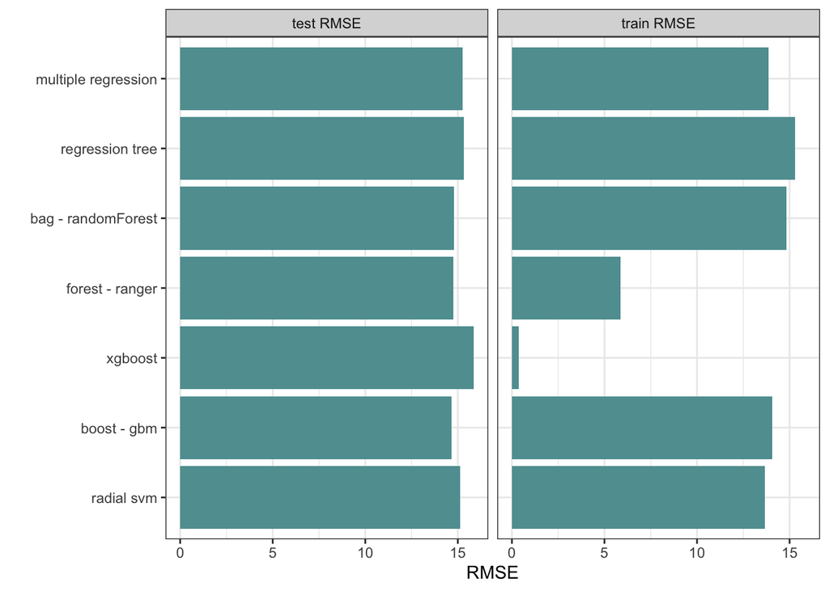

```r
data.frame(
  id = 1:7,
  model = c('multiple regression','regression tree','bag - randomForest','forest - ranger', 'xgboost','boost - gbm','radial svm' ),
  rmse_train = c(rmse_train_lm, rmse_train_tree, rmse_train_rf, rmse_train_cv_forest_ranger, rmse_train_xgboost, rmse_train_cv_boost, rmse_train_svm),
  rmse = c(rmse_test_lm, rmse_test_tree, rmse_test_rf, rmse_test_cv_forest_ranger, rmse_test_xgboost, rmse_test_cv_boost, rmse_test_svm))%>%
  rename('train RMSE' = rmse_train, 'test RMSE' = rmse)%>%
  pivot_longer(cols = 3:4,names_to = 'Sample', values_to = 'RMSE')%>%
  ggplot(aes(x=reorder(model,desc(id)), y = RMSE))+
  geom_col(fill = 'cadetblue')+
  xlab('')+
  coord_flip()+
  theme_bw()+
  facet_wrap(~Sample)
```

Interestingly, eventhough XGBoost get a very low train RMSE (0.37), the test RMSE is the highest (15.85). XGBoost derives the most extreme over-fitting issue here.

We can clearly see that Random Forest, Ranger, and gbm models work the best (get the lowest test RMSE) for test samples. Therefore, we pick these three models for further parameters tuning.

# Data Analysis - Model Tuning

I turned several times for Random Forest, Ranger, and gbm models. The best results and the critical steps for the iterative (decreasing test RMSE and improving predictive accuracy of models) process are shown below.

## Random Forest - Tuned Model Parameters

Tuned Bagging (Random Forest) gets a 14.75 test RMSE.

```r
set.seed(1031)
bag_rf = randomForest(rating~.,
                   data=train_components,
                   mtry = 36,
                   ntree = 1000)
pred_train_rf = predict(bag_rf)
rmse_train_rf = sqrt(mean((pred_train_rf - train_components$rating)^2)); rmse_train_rf
```

```
## [1] 14.81577
```

```r
pred_test_rf = predict(bag_rf, newdata=test_components)
rmse_test_rf = sqrt(mean((pred_test_rf - test_components$rating)^2)); rmse_test_rf
```

```
## [1] 14.75382
```

## Ranger - Tuned Model Parameters

Tuned Random Forest (Ranger) gets a 14.65 test RMSE.

```r
set.seed(627143)
cv_forest_ranger = ranger(rating ~ .,
                          data=train_components,
                          num.trees = 1000,
                          mtry=36,
                          min.node.size = 30,
                          splitrule = "extratrees")
#test ranger rmse
pred_train = predict(cv_forest_ranger, data = train_components, num.trees = 1000)
rmse_train_cv_forest_ranger = sqrt(mean((pred_train$predictions - train_components$rating)^2)); rmse_train_cv_forest_ranger
```

```
## [1] 11.6772
```

```r
pred_test = predict(cv_forest_ranger, data = test_components, num.trees = 1000)
rmse_test_cv_forest_ranger = sqrt(mean((pred_test$predictions - test_components$rating)^2)); rmse_test_cv_forest_ranger
```

```
## [1] 14.64986
```

## gbm - Tuned Model Parameters

Tuned Boosting (gbm) gets a 14.53 test RMSE.

```r
set.seed(1031)
cvboost = gbm(rating ~ .,
              data=train_components,
              distribution="gaussian",
              n.trees=1000,
              interaction.depth=10,
              shrinkage=0.02,
              n.minobsinnode = 1)

#test gbm rmse
pred_train = predict(cvboost, n.trees = 1000)
rmse_train_cv_boost = sqrt(mean((pred_train - train_components$rating)^2)); rmse_train_cv_boost
```

```
## [1] 12.39256
```

```r
pred_test = predict(cvboost, newdata = test_components, n.trees = 1000)
rmse_test_cv_boost = sqrt(mean((pred_test - test_components$rating)^2)); rmse_test_cv_boost
```

```
## [1] 14.52983
```

## gbm - Changed PCA Parameters

I changed PCA to higher variation (80%) of predictor selection, and the tuned Boosting (gbm) gets a 14.51 test RMSE.

```r
#feature selection - pca changed to 80%
#analysisdata
trainPredictors = train[,-1]
pca = prcomp(trainPredictors,scale. = T)
train_components = data.frame(rating = train$rating, cbind(pca$x[,1:1664*0.8]))

testPredictors = test[,-1]
test_pca = predict(pca,newdata=testPredictors)
test_components = data.frame(rating = test$rating, cbind(test_pca[,1:1664*0.8]))

#scoringdata
sdata6_pca = predict(pca,newdata=sdata6)
sdata6_components = data.frame(sdata6_pca[,1:1664*0.8])


#gbm
set.seed(1031)
cvboost = gbm(rating ~ .,
              data=train_components,
              distribution="gaussian",
              n.trees=1000,
              interaction.depth=10,
              shrinkage=0.02,
              n.minobsinnode = 1)

#test gbm rmse
pred_train = predict(cvboost, n.trees = 1000)
rmse_train_cv_boost = sqrt(mean((pred_train - train_components$rating)^2)); rmse_train_cv_boost
```

```
## [1] 12.14556
```

```r
pred_test = predict(cvboost, newdata = test_components, n.trees = 1000)
rmse_test_cv_boost = sqrt(mean((pred_test - test_components$rating)^2)); rmse_test_cv_boost
```

```
## [1] 14.50807
```

## gbm - Changed Seed

I changed PCA to higher variation (80%) of predictor selection, and then changed seed before training the model. Furthermore, I tuned the model parameters again.

Tuned Boosting (gbm) gets a 14.44 test RMSE, which is the best accuracy I get from the models.

```r
set.seed(627143)
cvboost = gbm(rating ~ .,
              data=train_components,
              distribution="gaussian",
              n.trees=500,
              interaction.depth=12,
              shrinkage=0.013,
              n.minobsinnode = 1)

#test gbm rmse
pred_train = predict(cvboost, n.trees = 500)
rmse_train_cv_boost = sqrt(mean((pred_train - train_components$rating)^2)); rmse_train_cv_boost
```

```
## [1] 13.3457
```

```r
pred_test = predict(cvboost, newdata = test_components, n.trees = 500)
rmse_test_cv_boost = sqrt(mean((pred_test - test_components$rating)^2)); rmse_test_cv_boost
```

```
## [1] 14.43914
```

# Prediction

Finally, I fit this model into scoringData, to generate the prediction data set for final submission.

```r
pred = predict(cvboost, newdata = sdata6_components, n.trees = 500)
submissionFile=data.frame(id=sdata6_id$id,rating=pred)
write.csv(submissionFile, file="submission_17_20.csv", row.names=F)
```

# Discussion about Mistake (PCA)

Although I made a mistake during the competition, I want to re-do the Principal Components Analysis correctly and see what will be the final results.

```r
trainPredictors = train[,-1]
pca = prcomp(trainPredictors,scale. = T)
train_components = data.frame(rating = train$rating, cbind(pca$x[,1:(1664*0.8)]))

testPredictors = test[,-1]
test_pca = predict(pca,newdata=testPredictors)
test_components = data.frame(rating = test$rating, cbind(test_pca[,1:(1664*0.8)]))
str(train_components)
```

```
## 'data.frame':    13638 obs. of  1332 variables:
##  $ rating: num  36 70 64 19 34 44 34 47 30 55 ...
##  $ PC1   : num  -1.8592 1.7006 1.3401 -0.0335 0.9193 ...
##  $ PC2   : num  2.827 -0.57 -0.57 1.146 0.147 ...
##  $ PC3   : num  -0.693 0.967 0.988 1.043 2.46 ...
##  $ PC4   : num  3.049 -0.19 0.353 2.178 1.882 ...
##  $ PC5   : num  -0.167 -0.824 -0.911 -1.748 -3.594 ...
##  $ PC6   : num  0.0342 -0.8325 -0.5826 -0.5704 -1.1054 ...
##  $ PC7   : num  -0.759 0.996 0.848 1.332 3.289 ...
##  $ PC8   : num  -0.1046 -0.0297 -0.0856 -0.1552 -0.4854 ...
##  $ PC9   : num  -1.287 0.292 0.361 0.69 2.2 ...
##  $ PC10  : num  0.196 1.011 0.487 -0.512 -1.437 ...
##  $ PC11  : num  1.016 1.715 0.933 -0.843 -2.872 ...
##  $ PC12  : num  0.0109 1.4133 0.9287 -1.4183 -3.5119 ...
##  $ PC13  : num  0.5942 0.3156 0.0914 0.9925 1.0326 ...
```

[output cut: 86 more lines]

```r
#scoringdata
sdata6_pca = predict(pca,newdata=sdata6)
sdata6_components = data.frame(sdata6_pca[,1:(1664*0.8)])

set.seed(627143)
cvboost = gbm(rating ~ .,
              data=train_components,
              distribution="gaussian",
              n.trees=500,
              interaction.depth=12,
              shrinkage=0.013,
              n.minobsinnode = 1)

#test gbm rmse
pred_train = predict(cvboost, n.trees = 500)
rmse_train_cv_boost = sqrt(mean((pred_train - train_components$rating)^2)); rmse_train_cv_boost
```

```
## [1] 13.3457
```

```r
pred_test = predict(cvboost, newdata = test_components, n.trees = 500)
rmse_test_cv_boost = sqrt(mean((pred_test - test_components$rating)^2)); rmse_test_cv_boost
```

```
## [1] 14.43914
```

```r
pred = predict(cvboost, newdata = sdata6_components, n.trees = 500)
submissionFile_redo=data.frame(id=sdata6_id$id,rating=pred)
library(diffdf)
diffdf(submissionFile_redo, submissionFile)
```

```
## No issues were found!
```